# Week 5 — Effect Modification and Interaction

SPPH 604 · Application of Advanced Epidemiological Methods

Running example: obesity, waist fat and death in MASLD (Kueh et al. 2026)

## Two questions hiding in the same 2 × 2 table

| Group | Obese? | Waist fat (WHtR) | People | Deaths |
| --- | --- | --- | --- | --- |
| I | yes | lower (< 0.6) | 355 | **4** (1.1%) |
| II | yes | high (>= 0.6) | 4,265 | 362 (8.5%) |
| III | no | lower | 732 | 67 (9.2%) |
| IV | no | high | 559 | 101 (18.1%) |

**Question 1 — effect modification:** does **waist fat’s effect** differ by obesity?  
**Question 2 — interaction:** what do **obesity and waist fat together** do, compared with each alone?

Same table. **Different causal question.** Today we will learn the clean distinction first, then see why the real MASLD example is harder.

Same 5,911 people as Week 4. WHtR = waist-to-height ratio.

## The map for today

By the end of today, you should be able to answer **five questions in order**:

1. Am I changing **one exposure** or imagining **two exposures jointly**?
2. What is my modifier M, and could **A change M**?
3. On what **scale** am I comparing effects — additive or multiplicative?
4. What do the **four cells** actually contain?
5. What should I **report**, with uncertainty, without over-interpreting it?

A model term such as `A * M` comes **after** these questions. It does not define the scientific question for you.

# Part 1 · Learn the distinction on a clean example

Same 2 × 2 table, two different questions.

## Start with smoking, income, and hypertension

Imagine a **fixed follow-up** study:

- **A = smoking** during the exposure window
- **M = low income**, measured before that exposure window
- **Y = incident hypertension** by the end of follow-up

| Risk of hypertension | Higher income (M = 0) | Low income (M = 1) |
| --- | --- | --- |
| **Not smoking (A = 0)** | 5% | 15% |
| **Smoking (A = 1)** | 10% | 30% |

For this teaching example, assume income is established **before** the smoking exposure window, so smoking cannot move someone between the income strata.

Before any model, read the table in **two ways**: smoking’s effect **within income groups**, or the joint pattern across **all four cells**.

## Question 1: effect modification

**One exposure: smoking. Income defines the groups.** Ask whether smoking’s effect on hypertension is the same in each income stratum.

|  | Higher income | Low income |
| --- | --- | --- |
| Risk if not smoking | 5% | 15% |
| Risk if smoking | 10% | 30% |
| **Risk difference for smoking** | **+5 points** | **+15 points** |
| **Risk ratio for smoking** | **2.0** | **2.0** |

- Additive scale: **yes**, smoking’s effect differs (+5 vs +15 points)
- Multiplicative scale: **no**, the smoking RR is 2 in both income groups

Effect modification is really **effect-measure modification**: the answer can depend on the scale.

## In R: read smoking’s effect within each income group

```r
toy <- data.frame(
  income = c("Higher", "Low"),
  risk_nonsmoke = c(0.05, 0.15),
  risk_smoke    = c(0.10, 0.30)
)

toy$RD <- toy$risk_smoke - toy$risk_nonsmoke
toy$RR <- toy$risk_smoke / toy$risk_nonsmoke
toy
```

```
#>   income risk_nonsmoke risk_smoke   RD RR
#> 1 Higher          0.05        0.1 0.05  2
#> 2    Low          0.15        0.3 0.15  2
```

The code does exactly what the table did: compare **smoking vs not smoking within each income group**.

## Question 2: interaction

Now make a **stronger move**: treat smoking and low income as **two exposures** and use the higher-income, non-smoking cell as the reference.

- RR for smoking alone = 10% / 5% = **2**
- RR for low income alone = 15% / 5% = **3**
- RR for both = 30% / 5% = **6**

**Multiplicative:** 6 = 2 × 3 → **no multiplicative interaction**

**Additive interaction contrast (IC):** compare the smoking risk difference across income groups:

$$IC=(R_{11}-R_{01})-(R_{10}-R_{00})
=R_{11}-R_{10}-R_{01}+R_{00}.$$

Here, IC = (30 − 15) − (10 − 5) = **+10 percentage points**. The additive null is **IC = 0**.

The arithmetic is valid, but the **causal interpretation is stronger**. Treating income as a second exposure asks what it means to intervene on income; that may represent several different social interventions. As a modifier, income only had to define a defensible pre-exposure subgroup.

## In R: interaction on two scales

```r
r00 <- 0.05  # higher income, not smoking
r10 <- 0.10  # higher income, smoking
r01 <- 0.15  # low income, not smoking
r11 <- 0.30  # low income, smoking

rr10 <- r10 / r00
rr01 <- r01 / r00
rr11 <- r11 / r00

mult_ratio <- rr11 / (rr10 * rr01)
IC <- r11 - r10 - r01 + r00
round(c(mult_ratio = mult_ratio, IC = IC), 2)
```

```
#> mult_ratio         IC
#>        1.0        0.1
```

`mult_ratio = 1` is the multiplicative null. `IC = 0.10` means the smoking risk difference is **10 percentage points larger in the low-income group** than in the higher-income group.

## Same table, different question

|  | Effect modification | Interaction |
| --- | --- | --- |
| What changes? | **Smoking (A) only** | **Smoking and low income** |
| Role of income (M) | defines pre-exposure groups | second exposure |
| Main comparison | smoking’s effect within each income group | all four joint exposure states |
| Causal demand | identify smoking → hypertension within income strata | identify joint effects of smoking and income |
| Scale | additive **or** multiplicative | additive **or** multiplicative |

**Effect modification imagines changing one variable; interaction imagines changing two.**

**Read more** · EpiMethods *Concepts*, [“Formal Definitions”](https://ehsanx.github.io/EpiMethods/confounding0.html#formal-definitions) · VanderWeele, *Epidemiology* 2009 · Bours, *J Clin Epidemiol* 2021

## Confounding is a third idea

|  | What it means | What you do |
| --- | --- | --- |
| **Confounding** | a common cause biases an estimate | **control** it |
| **Effect modification** | A’s effect differs across M | **describe** stratum-specific effects |
| **Interaction** | the joint effect of A and M departs from a chosen scale | **describe** all four exposure states |
| **Product term A × M** | a model parameter | use it as a **tool**, on that model’s scale |

A product term is not synonymous with either “effect modification” or “interaction”. The **question and estimand come first**.

# Part 2 · A practical workflow for effect modification

This is the main skill for P3.

## A five-step workflow

1. **Choose A and M.** Give a substantive reason for M.
2. Check that **A cannot cause M**.
3. **Count** people and outcomes in A × M before modelling.
4. Estimate A’s effect within each M on a **named scale**.
5. Report the two effects, their **contrast and uncertainty**, and what you adjusted for.

Do this before asking whether a p-value crossed 0.05.

## The modifier must survive the “could A change it?” test

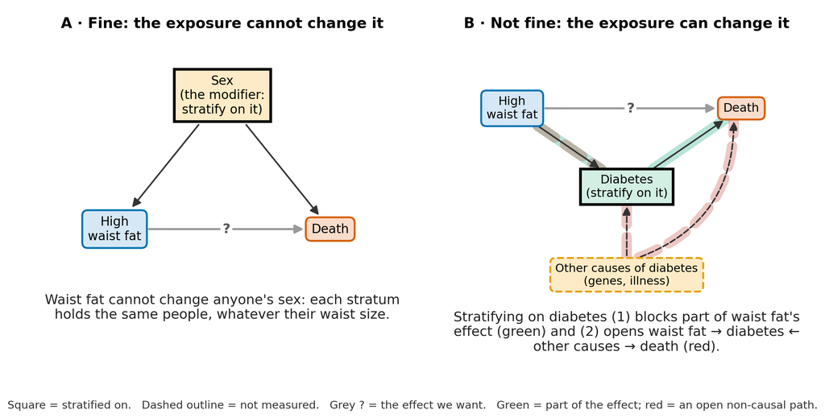

“A’s effect among people with M = m” is cleanest when **A cannot move people into or out of M**. Sex, age, genes, or a condition established before A are natural candidates. A condition measured at the same visit may not be.

If A could cause M, stratifying on M may block part of A’s effect or induce selection/collider bias. That is no longer a simple subgroup effect. In the smoking example, this is why we explicitly defined **income before the smoking exposure window**.

## What do we adjust for?

### Effect modification of A by M

We need to identify the **effect of A on Y within levels of M**.

- Control the confounding of **A → Y** appropriate to that question
- We do **not** need to identify the causal effect of M itself
- But conditioning on M still has to be **causally defensible**

### Interaction of A and M

To interpret both as exposures, we need to identify the **joint effects of A and M** — a stronger requirement.

The adjustment set follows the **causal question**, not the presence of `A * M` in software.

**Read more** · EpiMethods *Concepts*, [“Implications for Confounding Control”](https://ehsanx.github.io/EpiMethods/confounding0.html#implications-for-confounding-control) · Karim, ch. 8

## Name the scale before saying “no modification”

*Week 4’s made-up table, now read for effect modification.*

| Age group | Risk, exposed | Risk, unexposed | OR | RR | RD |
| --- | --- | --- | --- | --- | --- |
| 60 or older | 0.80 | 0.50 | 4.00 | **1.60** | 0.30 |
| Under 60 | 0.50 | 0.20 | 4.00 | **2.50** | 0.30 |

- RR: **modified** by age (1.60 vs 2.50)
- OR: **not modified** (4.00 vs 4.00)
- RD: **not modified** (0.30 vs 0.30)

Never write “there is no effect modification” without naming the **scale**.

## Two scales are enough for the core lecture

### Multiplicative

Compare the **relative effects** of A across M.

For a Cox model:

**ratio of HRs** = HR(A | M=1) ÷ HR(A | M=0)

No multiplicative modification → **ratio = 1**

### Additive

Compare the **absolute effects** of A across M.

**difference of RDs** = RD(A | M=1) − RD(A | M=0)

No additive modification → **difference = 0**

For public-health interpretation, the additive scale often answers the concrete question: **how many extra events are associated with the exposure in each subgroup?**

# Part 3 · Now stress-test the idea with MASLD

The paper is prognostic; our causal re-reading is harder.

## The MASLD question we will try to answer

- **A:** high waist fat, WHtR >= 0.6
- **M:** obesity
- **Y:** all-cause death
- **L:** age, sex, race/ethnicity, smoking, sedentary time

**Primary Week 5 question:** does the effect of high waist fat on death differ between people with and without obesity?

That is an **effect-modification** question: one exposure changes; obesity defines the strata. The paper itself asked a **prognostic phenotype** question; this causal re-reading is ours.

This lecture’s analysis: the same 5,911 rows as Week 4, adjusted for L, unweighted (weights are Week 6). Slides that use other rows say so.

## Why the MASLD example becomes causally difficult

The paper’s phenotype analysis is reasonable for **risk stratification**. Extra problems appear when we reuse the same data for a causal effect-modification question:

- BMI/obesity and WHtR/waist were measured at the **same examination**; the data do not establish which came first
- both are related measures of adiposity, so treating obesity as clearly upstream of waist fat is a **substantive assumption**
- the cohort is restricted to people with **MASLD**; MASLD ascertainment depends partly on BMI and waist-related information
- one important cell is sparse: the paper had **5 deaths** in Group I; our complete-case analysis has **4**

Nothing here makes the paper “wrong.” These complications arise because **we are asking a different, more causal question than the paper was designed to answer**.

## Causal audit: can obesity really be the modifier?

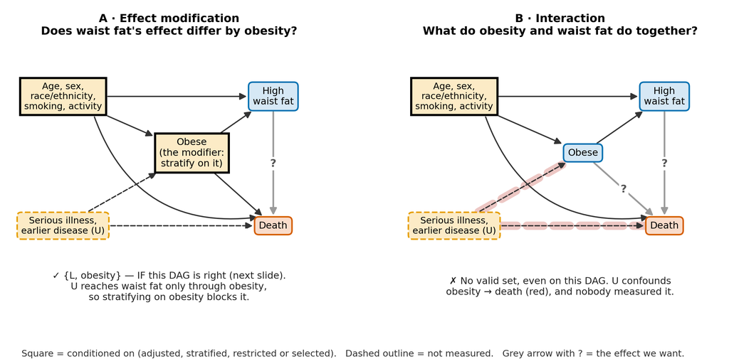

Panel A can represent effect modification only under strong assumptions, including that obesity comes **before** waist fat. Panel B treats obesity as a second exposure and exposes an unmeasured confounding problem for obesity → death.

## What the effect-modification interpretation assumes

For the obese/not-obese strata to be interpretable as modifiers of waist fat’s effect, we need:

- a time-ordering story in which obesity is established **before** the waist-fat exposure of interest
- no important unmeasured common cause of obesity and waist fat that becomes problematic when we stratify on obesity
- L to be adequate for confounding of waist fat → death within each obesity stratum
- conditioning on MASLD **not to induce important selection bias** in the within-stratum waist-fat comparison

The last assumption is not testable here. FLI, used to identify steatosis, includes **BMI and waist circumference** (plus triglycerides and GGT), so restricting to MASLD can in principle distort the association between adiposity measures and death.

## Count first

|  | Lower waist fat | High waist fat |
| --- | --- | --- |
| **Obese** | Group I: 355 people, **4 deaths** | Group II: 4,265 people, 362 deaths |
| **Not obese** | Group III: 732 people, 67 deaths | Group IV: 559 people, 101 deaths |

- Group I anchors the obese waist-fat comparison **II vs I** and several phenotype contrasts; it contains only **4 deaths**
- Among 2,432 obese women, only **57** have lower waist fat: limited support for that exposure level

A model can still produce a coefficient, but the empirical information comes from these cells. **Report the cell counts beside the effect estimates.**

## In R: count before you model

```r
table(group = d$group, died = d$dead)
```

```
#>      died
#> group    0    1
#>   I    351    4
#>   II  3903  362
#>   III  665   67
#>   IV   458  101
```

```r
with(subset(d, obese == 1 & female == 1),
     table(high_waist = central))
```

```
#> high_waist
#>    0    1
#>   57 2375
```

Two lines of code reveal the problem before the Cox model does: **4 deaths in Group I** and very little lower-waist support among obese women.

## One product-term model, two stratum-specific HRs

```r
fit <- coxph(Surv(time_yr, dead) ~ obese * central +
               age + female + race + smk_current + sed, data = d)
```

- Among the **not obese**: HR for high vs lower waist fat = **1.09 (0.79–1.50)**
- Among the **obese**: HR = **2.99 (1.11–8.09)**
- Ratio of HRs = **2.74 (0.97–7.71)** (Wald 95% CI)
- Tests for allowing the HR to differ: **Wald p = 0.06; likelihood-ratio p = 0.03**

$$\exp(\beta_{A\times M})
=\frac{ HR_\text{waist, obese} }{ HR_\text{waist, not obese} }
=\frac{2.99}{1.09}=2.74.$$

The product term **re-parameterises the same four cells**. It compares the two HRs; it does not create information where Group I has only four deaths.

## In R: recover both HRs and test the product term

```r
b <- coef(fit)

round(exp(b[["central"]]), 2)                      # not obese: IV vs III
```

```
#> [1] 1.09
```

```r
round(exp(b[["central"]] + b[["obese:central"]]), 2)   # obese: II vs I
```

```
#> [1] 2.99
```

```r
fit_main <- coxph(Surv(time_yr, dead) ~ obese + central +
                    age + female + race + smk_current + sed, data = d)
round(anova(fit_main, fit)$`Pr(>|Chi|)`[2], 3)     # likelihood-ratio p
```

```
#> [1] 0.029
```

The stratum-specific effects are the scientific results; the product-term test is a **contrast between them**.

## Why compute standardised six-year risks?

This is **our re-analysis, not a result reported by the paper**. The paper reports Kaplan-Meier curves and Cox hazard ratios. We add standardised risks because effect modification can also be asked on an **absolute, additive scale**.

For a survival outcome we must choose a time horizon. At **6 years**, within each obesity stratum:

1. take the **same people** with their observed age, sex, race/ethnicity, smoking, and sedentary time
2. set everyone’s waist-fat exposure to **lower**, predict risk by 6 years, and average
3. set those same people’s waist-fat exposure to **high**, predict again, and average
4. subtract the two average risks

A six-year risk is (1-S(6)). Standardisation averages those model-predicted risks over the covariate distribution of the people in that obesity stratum.

## Additive scale: the standardised six-year results

| Obesity stratum | If everyone had lower waist fat | If everyone had high waist fat | Risk difference |
| --- | --- | --- | --- |
| **Obese** | 2.3% | 6.4% | **+4.1 points** |
| **Not obese** | 9.1% | 9.8% | **+0.7 points** |

Difference of risk differences = **+3.4 percentage points**  
Bootstrap 95% CI: **−0.1 to +6.6 points**

Interpretation: by 6 years, the model predicts about **4.1 extra deaths per 100** with high versus lower waist fat among the obese, versus about **0.7 per 100** among the not obese.

The displayed R code on the next slide calculates the point estimates. The interval comes from a nonparametric bootstrap that refits the model in each resample.

## In R: use the same people twice, changing only waist fat

```r
# fit is the Cox model from the preceding slides
risk6 <- function(people, waist) {
  nd <- people                 # same people, same L values
  nd$central <- waist          # change only high-waist exposure
  s6 <- summary(survfit(fit, newdata = nd), times = 6)$surv
  mean(1 - s6)                 # average predicted 6-year risk
}

ob    <- subset(d, obese == 1)
notob <- subset(d, obese == 0)

r <- c(
  obese_low     = risk6(ob,    0),
  obese_high    = risk6(ob,    1),
  notobese_low  = risk6(notob, 0),
  notobese_high = risk6(notob, 1)
)
round(100 * r, 1)
```

```
#>     obese_low    obese_high  notobese_low notobese_high
#>           2.3           6.4           9.1           9.8
```

## In R: turn the four predictions into risk differences

```r
rd <- 100 * c(
  obese     = r[["obese_high"]]    - r[["obese_low"]],
  not_obese = r[["notobese_high"]] - r[["notobese_low"]]
)
round(rd, 1)
```

```
#>     obese not_obese
#>       4.1       0.7
```

```r
round(rd[["obese"]] - rd[["not_obese"]], 1)   # difference of risk differences
```

```
#> [1] 3.4
```

The code mirrors the estimand: **high minus lower waist fat within each obesity stratum**, then compare those two risk differences.

## Put both scales on one page

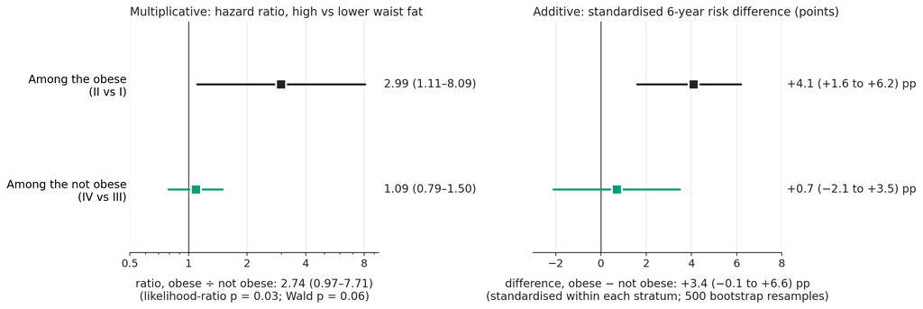

A reasonable report is: **waist fat may have a larger effect among the obese**, on both the hazard-ratio and six-year risk-difference scales, but the estimate is unstable and depends heavily on a reference cell with only **four deaths**.

## The paper’s IV vs I comparison asks a different question

| Comparison | What changes? | What question does it answer? |
| --- | --- | --- |
| **II vs I** | waist fat only | waist-fat association among the **obese** |
| **IV vs III** | waist fat only | waist-fat association among the **not obese** |
| **IV vs I** | **obesity status and waist fat** | prognosis of phenotype IV versus phenotype I |

Our effect-modification question uses the two **within-row** comparisons: II vs I and IV vs III. The paper’s IV vs I contrast is **diagonal** across the 2 × 2 table.

The paper’s IV vs I comparison is not wrong. It is useful for **phenotype risk stratification**. It is simply **not the effect of high waist fat among the not obese**; that contrast is IV vs III.

# Part 4 · Interaction, survival tools, and reporting

Now change the question deliberately.

## If obesity is a second exposure, the estimand changes

Now deliberately treat both variables as exposures, keeping the coding consistent:

- **A = high waist fat** (1 = high, 0 = lower)
- **M = obesity** (1 = obese, 0 = not obese)
- each person now has four joint potential outcomes, $Y(a,m)$

The interaction contrasts ask whether the waist-fat effect changes when obesity is also changed:

- **Multiplicative:** ratio of waist-fat HRs = **2.74 (0.97–7.71)**
- **Additive:** $IC=(R_{11}-R_{01})-(R_{10}-R_{00})$; using one common standardised population, **IC = +3.9 points**

The arithmetic is estimable, but a **causal** joint-exposure interpretation additionally requires identification of obesity’s effect. In our DAG, **U confounds obesity → death and is unmeasured**.

## In R: interaction with the same A and M coding

```r
# Multiplicative interaction from the Cox product term
b <- coef(fit)
round(exp(b[["obese:central"]]), 2)   # HR(waist | obese) / HR(waist | not obese)
```

```
#> [1] 2.74
```

## In R: the additive interaction contrast

For the additive joint-exposure contrast, put **all four joint states in the same target population**:

```r
# A = high waist, M = obesity
# R00 = Group III; R10 = IV; R01 = I; R11 = II
risk6_all <- function(waist, obese) {   # everyone, set to one joint state
  nd <- d; nd$central <- waist; nd$obese <- obese
  mean(1 - summary(survfit(fit, newdata = nd), times = 6)$surv)
}
R <- c(R00 = risk6_all(0, 0), R10 = risk6_all(1, 0),
       R01 = risk6_all(0, 1), R11 = risk6_all(1, 1))
round(100 * R, 1)
```

```
#> R00 R10 R01 R11
#> 6.9 7.5 2.5 7.0
```

```r
IC <- 100 * (R[["R11"]] - R[["R01"]] - R[["R10"]] + R[["R00"]])
round(IC, 1)   # percentage points
```

```
#> [1] 3.9
```

Why **3.9** here but **3.4** for effect modification? Effect modification averaged within each obesity stratum; joint interaction standardises all four exposure states to **one common population**. They are related, but not identical, estimands.

## The right survival tool depends on the scale

| Goal | Tool | MASLD effect-modification result |
| --- | --- | --- |
| Multiplicative | Cox `A * M` → ratio of HRs | **2.74 (0.97–7.71)** |
| Additive | standardised risk at a fixed time → difference of RDs | **+3.4 (−0.1 to +6.6) points** |

- Do **not** turn a censored survival outcome into “ever died” and fit ordinary logistic regression
- A fixed-follow-up binary outcome is different; then a binary regression model may be appropriate

For survival outcomes, define the time horizon for an absolute effect: here, **six years**. The standardised risks are **our Week 5 re-analysis**, not quantities reported in the paper.

## A dramatic subgroup claim can be built on almost no information

These are **crude diagonal phenotype comparisons** (Group IV vs Group I), fitted separately by sex. They are **not** sex-specific waist-fat effects.

|  | Men | Women |
| --- | --- | --- |
| HR, IV vs I | **36.14 (8.86–147.48)** | **4.11 (0.99–17.12)** |
| Group I deaths / people | **2 / 317** | **2 / 58** |

The apparent 36-versus-4 gap is dramatic, but each reference survival experience contains only **two deaths**, and both confidence intervals are extremely wide. Do not build a biological story from it.

Crude, unweighted, on the 6,048-row locked domain (`dom` in the code), so Group I has 375 people here, not the 355 of the 5,911.

## In R: reproduce the crude IV-vs-I HRs

```r
dom$group <- relevel(factor(dom$group), ref = "I")

fit_men <- coxph(Surv(time_yr, dead) ~ group,
                 data = subset(dom, female == 0))
fit_women <- coxph(Surv(time_yr, dead) ~ group,
                   data = subset(dom, female == 1))

round(summary(fit_men)$conf.int[
  "groupIV", c("exp(coef)", "lower .95", "upper .95")], 2)
```

```
#> exp(coef) lower .95 upper .95
#>     36.14      8.86    147.48
```

```r
round(summary(fit_women)$conf.int[
  "groupIV", c("exp(coef)", "lower .95", "upper .95")], 2)
```

```
#> exp(coef) lower .95 upper .95
#>      4.11      0.99     17.12
```

Because Group I is the reference, `groupIV` is exactly the crude **IV vs I** phenotype HR, calculated separately in men and women.

## In R: now count the reference events

```r
with(subset(dom, group == "I"), table(female, died = dead))
```

```
#>       died
#> female   0   1
#>      0 315   2
#>      1  56   2
```

Group I contributes only **2 deaths in men and 2 deaths in women**. That is why the sex-specific IV-vs-I HRs are so unstable despite their dramatic point estimates.

## Ask the subgroup question cleanly

For the locked waist-fat contrast **IV vs III**, with sex as the modifier (all unweighted):

| Model | Ratio of HRs, women ÷ men | LRT p | Rows |
| --- | --- | --- | --- |
| Crude | 0.62 (0.26–1.43) | 0.278 | 1,296 |
| Paper’s Model 1 | 1.00 (0.42–2.35) | 0.993 | 1,296 |
| Week 4 pre-exposure set | **1.13 (0.48–2.66)** | **0.78** | 1,291 |

Additive six-year RDs are also imprecise: about **+0.8 points in men** and **+0.7 in women** (P3, Model 1).

At this precision there is **no clear evidence of sex modification**, but the interval still allows important differences in either direction.

1,296: P3’s paper-replication refits (Groups III + IV complete on the paper’s Model 1). 1,291 (168 deaths): Groups III + IV of our 5,911. CIs use Wald; p-values use likelihood-ratio tests.

## In R: one test for sex modification on the locked contrast

```r
s34 <- subset(d, group %in% c("III", "IV"))
s34$IV <- as.integer(s34$group == "IV")

f0 <- coxph(Surv(time_yr, dead) ~ IV + female +
              age + race + smk_current + sed, data = s34)
f1 <- coxph(Surv(time_yr, dead) ~ IV * female +
              age + race + smk_current + sed, data = s34)

round(summary(f1)$conf.int["IV:female", c(1, 3, 4)], 2)   # ratio of HRs
```

```
#> exp(coef) lower .95 upper .95
#>      1.13      0.48      2.66
```

```r
round(anova(f0, f1)$`Pr(>|Chi|)`[2], 2)   # likelihood-ratio p
```

```
#> [1] 0.78
```

One pre-specified contrast, one product-term test, and an interval wide enough to show the uncertainty.

## Honest subgroup reporting

1. **Pre-specify** a plausible modifier and explain why A cannot cause it
2. State the **question**: effect modification or joint interaction
3. **Count** people and outcomes in every A × M cell
4. Report A’s effect within each M on a **named scale**
5. Give the **contrast and interval**, not just a p-value
6. Do not invent a biological explanation for a noisy subgroup difference

**Read more** · Knol & VanderWeele, *Int J Epidemiol* 2012 · Karim, ch. 8, §8.7–8.8 · [Interaction tutorial: effect modification](https://ehsanx.github.io/interaction/effect-modification-1.html)

## The algorithm to take into your own paper

**1. One exposure or two?**  
Effect modification = one exposure across groups. Interaction = two exposures jointly.

**2. Can A change M?**  
If yes, simple subgroup effect modification may not be the right estimand.

**3. Which scale?**  
Report multiplicative and additive effects when they answer useful questions.

**4. What do the cells contain?**  
Sparse cells can dominate apparently dramatic interaction estimates.

## Key takeaways

- **Effect modification:** A’s effect differs across levels of M; for the usual causal subgroup interpretation, A should not determine M
- **Interaction:** the joint effect of A and M departs from additivity or multiplicativity
- The **scale matters**: the same data can modify one measure and not another
- The **question determines confounding control**; a product term does not
- With survival outcomes: Cox product term for the multiplicative scale; **standardised risks at a fixed time** for an additive scale
- In MASLD, the point estimates suggest more waist-fat harm among the obese, but the conclusion is fragile because the obese lower-waist cell anchoring **II vs I has only 4 deaths**

**Exit question:** name one modifier for your own paper, and give one sentence explaining why your exposure cannot change it.

# Appendix · Extensions and diagnostics

## Appendix: optional — one model, two parameterisations

```r
fit_joint <- coxph(Surv(time_yr, dead) ~ group +
                     age + female + race + smk_current + sed, data = d)
fit_prod  <- coxph(Surv(time_yr, dead) ~ obese * central +
                     age + female + race + smk_current + sed, data = d)
all.equal(fit_joint$loglik, fit_prod$loglik)
```

```
#> [1] TRUE
```

```r
round(exp(coef(fit_prod))[c("obese", "central", "obese:central")], 2)
```

```
#>         obese       central obese:central
#>          0.34          1.09          2.74
```

The four-level factor and product-term parameterisations give the same fitted model.

## Appendix: RERI, AP, S, and IC

For a four-cell joint-exposure table with a clearly defined (00) state:

- **RERI** = RR<sub>11</sub> − RR<sub>10</sub> − RR<sub>01</sub> + 1; null = 0
- **AP** = RERI / RR<sub>11</sub>; null = 0
- **S** = (RR<sub>11</sub> − 1) / [(RR<sub>10</sub> − 1) + (RR<sub>01</sub> − 1)]; null = 1
- **IC** = R<sub>11</sub> − R<sub>10</sub> − R<sub>01</sub> + R<sub>00</sub>; null = 0

In the core MASLD slides we keep **A = high waist fat** and **M = obesity** throughout. With the four joint states standardised to one common population, the six-year risk-scale **IC = +3.9 points**.

RERI, AP, and S depend on the chosen exposure/reference coding and are not emphasized here because the joint causal effect of obesity is not identified in this example. IC was defined at first use in the smoking-income example.

## Appendix: why diabetes is a risky modifier here

```r
tab <- table(diabetes = d$t2dm, high_waist = d$central)
round(100 * prop.table(tab, 2))
```

```
#>         high_waist
#> diabetes  0  1
#>        0 87 72
#>        1 13 28
```

Diabetes is more common among people with high waist fat (28% vs 13%). That does not prove waist fat causes diabetes, but it makes a same-visit diabetes stratum a poor choice for the simple pre-exposure-modifier interpretation.

## Appendix: what splitting by diabetes produces

```r
f_no  <- coxph(Surv(time_yr, dead) ~ central + obese + age + female +
                 race + smk_current + sed, data = subset(d, t2dm == 0))
f_yes <- coxph(Surv(time_yr, dead) ~ central + obese + age + female +
                 race + smk_current + sed, data = subset(d, t2dm == 1))
```

The waist-fat HR is about **1.23** without diabetes and **0.93** with diabetes, but neither number automatically has a clean causal subgroup interpretation if waist fat can affect diabetes.

## Where to read more

[output not shown]

## References (1/2)

- Banack HR, Kaufman JS. The obesity paradox: understanding the effect of obesity on mortality among individuals with cardiovascular disease. *Prev Med* 2014;62:96–102.
- Bours MJL. Tutorial: a nontechnical explanation of the counterfactual definition of effect modification and interaction. *J Clin Epidemiol* 2021;134:113–124.
- Hosmer DW, Lemeshow S. Confidence interval estimation of interaction. *Epidemiology* 1992;3:452–456.
- Karim ME. Effect modification in non-randomized studies: methods and applications with propensity scores. Chapter 8 (book chapter).
- Lajous M, Bijon A, Fagherazzi G, et al. Body mass index, diabetes, and mortality in French women: explaining away a “paradox”. *Epidemiology* 2014;25:10–14.
- Knol MJ, VanderWeele TJ. Recommendations for presenting analyses of effect modification and interaction. *Int J Epidemiol* 2012;41:514–520.

## References (2/2)

- Knol MJ, VanderWeele TJ, Groenwold RHH, et al. Estimating measures of interaction on an additive scale for preventive exposures. *Eur J Epidemiol* 2011;26:433–438.
- Kueh MTW, et al. Body weight categories and fat distribution in relation to all-cause mortality among adults with metabolic dysfunction-associated steatotic liver disease. *BMJ Open* 2026;16:e113719.
- VanderWeele TJ. On the distinction between interaction and effect modification. *Epidemiology* 2009;20:863–871.
- VanderWeele TJ, Knol MJ. A tutorial on interaction. *Epidemiol Methods* 2014;3:33–72.
- Westreich D, Greenland S. The Table 2 fallacy: presenting and interpreting confounder and modifier coefficients. *Am J Epidemiol* 2013;177:292–298.

## Appendix: the two questions as dagitty code

Paste into the *Model code* box at dagitty.net. With `Waist` as the only exposure, dagitty returns **{L, Obese}**. Mark `Obese` as an exposure too, and it reports that **no adjustment set exists** — until you remove the latent tag from `U`.

```
dag {
  Waist [exposure]  Death [outcome]  U [latent]
  L -> Obese  L -> Waist  L -> Death
  U -> Obese  U -> Death
  Obese -> Waist  Obese -> Death  Waist -> Death
}
```

`L` = age, sex, race/ethnicity, smoking, sedentary time. `U` = serious illness and disease that came before obesity (Week 4’s `Ill` and `Before`). Then test the assumptions: add `G [latent] G -> Obese G -> Waist`, or `FLI [adjusted] Waist -> FLI Waist -> TG TG -> FLI TG -> Death`, and watch every adjustment set disappear.